# Smart Crypto Stock Analysis (SCSA) Report - v0.1

Rodrigo Almeida dos Santos - rodrigo.almeida@gmail.com

13/01/2018

## Apresentação

O objetivo desse trabalho é, através de uma combinação de indicadores de análise técnica e algoritmos de inteligência artificial, selecionar uma ou mais estratégias com maior potencial de lucro nas operações de compra e venda de ativos financeiros.

Dividimos a análise em três seções:

- Na seção 1, iremos avaliar a evolução dos Ativos baseado em indicadores de Análise Técnica. Nessa seção iremos simular 15 estratégias de investimentos para um conjunto de ativos e selecionar automaticamente aqueles ativos/estratégias com maior potencial de retorno de investimento. Nessa seção também definiremos os benchmarks os quais serão submetidos os algoritmos de inteligência artificial.
- Na seção 2 iremos evoluir a aplicação da previsão incluindo algoritmos de Inteligência Artificial em uma ou mais das etapas de seleção de compra e venda de ativos. Confrotaremos os resultados obtidos com os algoritmos de IA e aqueles obtidos com análise técnica.
- Na seção 3 expandiremos a aplicação da Análise dos ativos tradicionais e trabalharemos na previsão das principais criptomoedas que estão disponíveis para operação no mercado.

## Seção 1 - Seleção Automática de Estratégias de Investimento

As seguintes estratégias de Investimento serão avaliadas (A partir da estratégia 11 utilizaremos multiplos indicadores):

- Estratégia 1: [Simple Moving Averages](https://www.investopedia.com/terms/s/sma.asp) & [Exponential Moving Averages](https://www.investopedia.com/terms/e/ema.asp) SMA(5 & 21) & EMA(5 & 21) Double Crossover
- Estratégia 2: [Bollinger Bands](https://www.investopedia.com/terms/b/bollingerbands.asp) BB(20,2)
- Estratégia 3: [Parabolic Stop And Reverse](https://www.investopedia.com/articles/technical/02/042202.asp) SAR(0.02,0.2)
- Estratégia 4: [Average Directional Movement Index](https://www.investopedia.com/terms/a/adx.asp) ADX(14)
- Estratégia 5: [Commodity Channel Index](https://www.investopedia.com/terms/c/commoditychannelindex.asp) CCI(20,0.015)
- Estratégia 6: [Moving Averages Covergence/Divergence](https://www.investopedia.com/terms/m/macd.asp) MACD(12,26,9)
- Estratégia 7: [Rate Of Change](https://www.investopedia.com/terms/p/pricerateofchange.asp) ROC(21)
- Estratégia 8: [Relative Strength Index](https://www.investopedia.com/terms/r/rsi.asp) RSI(14)
- Estratégia 9: [Stochastic Momentum Index](https://www.investopedia.com/ask/answers/021315/what-difference-between-stochastic-oscillator-stochastic-momentum-index.asp) SMI(13,2,25,9)
- Estratégia 10: [Williams %R(14)](https://www.investopedia.com/terms/w/williamsr.asp)
- Estratégia 11: Commodity Channel Index CCI(20,0.015) and Simple Moving Average SMA(5)
- Estratégia 12: Rate Of Change ROC(21) and Simple Moving Average SMA(5)
- Estratégia 13: Relative Strength Index RSI(14) and Simple Moving Average SMA(5)
- Estratégia 14: Stochastic Momentum Index SMI(13,2,25,9) and Simple Moving Average SMA(5)
- Estratégia 15: Williams %R(14) and Simple Moving Average SMA(5)

Os ativos selecionados estão listados no [site do yahoo](https://finance.yahoo.com/quote/%5EBVSP/components/). Selecionamos aleatoriamente 10 das ações da [carteira BOVESPA](http://www.bmfbovespa.com.br/pt_br/produtos/indices/indices-amplos/indice-ibovespa-ibovespa-composicao-da-carteira.htm) que estão entre os top 30 em volume de operações em 12/01/2018:

- Banco Bradesco S.A. (BBDC4)
- Raia Drogasil S.A. (RADL3)
- Lojas Americanas S.A. (LAME4)
- Braskem S.A. (BRKM5)
- Oi S.A. (OIBR4)
- Petroleo Brasileiro S.A (PETR4)
- Tim Participações S.A. (TIMP3)
- Banco do Brasil S.A. (BBAS3)
- Usinas Siderúrgicas de Minas Gerais S.A. (USIM5)
- Vale S.A. (VALE5)

### Análise da Estratégia Vencedora por Ação

A seguir, apresentamos a análise do comportamento das 10 ações no período de 12/01/2017 a 11/01/2018. Consideramos taxa de Corretagem de 1% para cada operação de compra ou venda. Para efeito de adoção da estratégia de investimento, comparamos o resultado de cada estratégia com o retorno diário de cada ação. Uma estratégia será selecionada somente se *o retorno da estratégia for melhor que o somatórios dos valores dos ganhos diários de cada ação*. Caso nenhuma estratégia supere o retorno diário, este será escolhido como valor de Benchmark.

| Ativo | Estrategia | Benchmark |
| --- | --- | --- |
| BBDC4 | Nenhuma | 0.2203 |
| RADL3 | Nenhuma | 0.3593 |
| LAME4 | SAR(0.02,0.2) | 0.2778 |
| BRKM5 | Nenhuma | 0.2321 |
| OIBR4 | CCI(20,0.015) & SMA(5) | 0.7164 |
| PETR4 | ADX(14) | 0.1337 |
| TIMP3 | Nenhuma | 0.531 |
| BBAS3 | ADX(14) | 0.3666 |
| USIM5 | Nenhuma | 1.2505 |
| VALE5 | BB(20,2) | 0.4006 |

### Sumário de Performance das Ações com Rendimento maior que o Retorno Diário

#### LAME4

Melhores Estratégias:

```
  estrategiasVencedoras     valoresRetornoVencedores
```

[1,] “SMA(5,21)” “-0.0623”  
[2,] “EMA(5,21)” “0.0046”  
[3,] “SAR(0.02,0.2)” “0.2778”  
[4,] “ADX(14)” “-0.0579”  
[5,] “MACD(12,26,9)S” “0.1023”  
[6,] “RSI(14)” “0.1918”  
[7,] “SMI(13,2,25,9)” “0.186”  
[8,] “CCI(20,0.015) & SMA(5)” “-0.043”  
[9,] “ROC(21) & SMA(5)” “0.0803”  
[10,] “RSI(14) & SMA(5)” “0.0382”  
[11,] “SMI(13,2,25,9) & SMA(5)” “0.1608”  
[12,] “%R(14) & SMA(5)” “-0.0304”

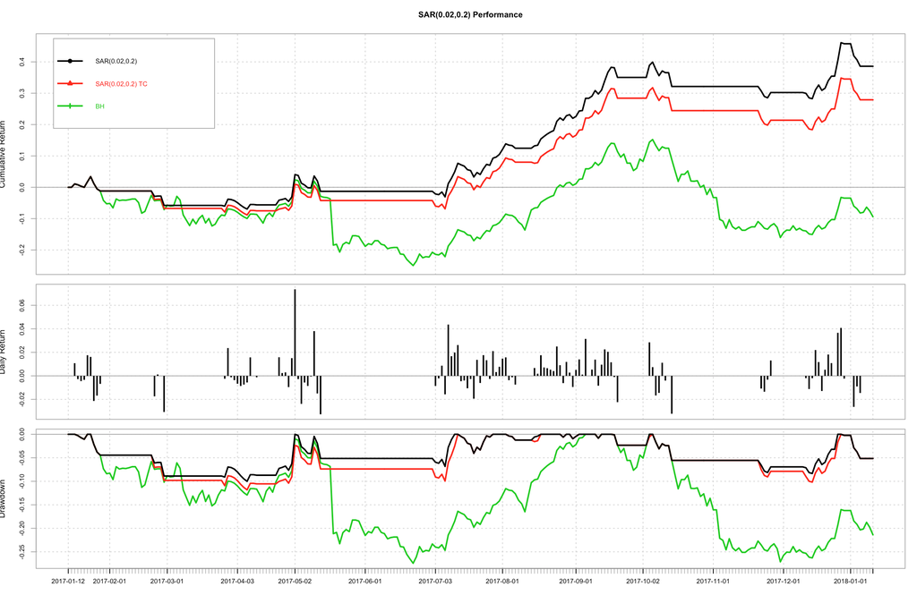

Sumário de Performance LAME4

#### OIBR4

Melhores Estratégias:

```
 estrategiasVencedoras    valoresRetornoVencedores
```

[1,] “BB(20,2)” “0.565”  
[2,] “CCI(20,0.015)” “0.3753”  
[3,] “CCI(20,0.015) & SMA(5)” “0.7164”

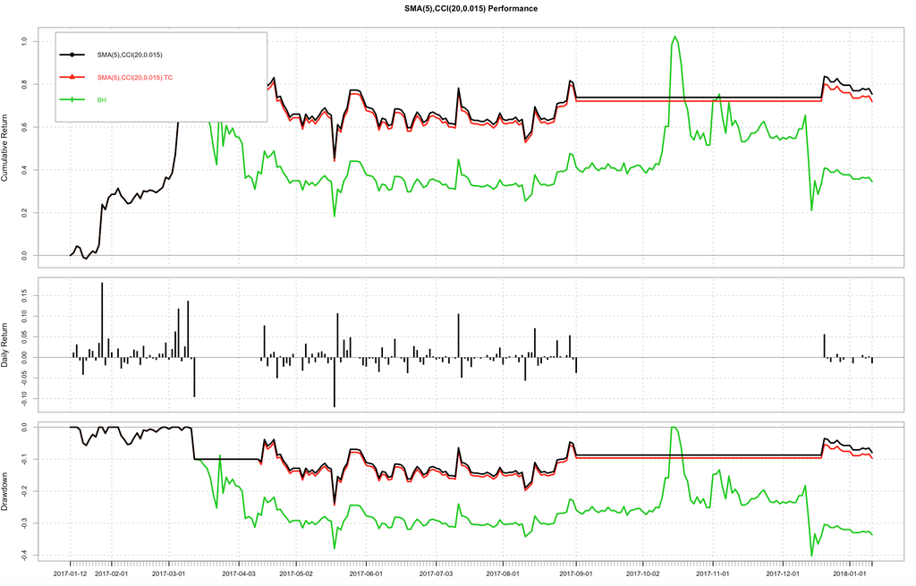

Sumário de Performance OIBR4

#### PETR4

Melhor Estratégia:

```
 estrategiasVencedoras valoresRetornoVencedores
```

[1,] “ADX(14)” “0.1337”

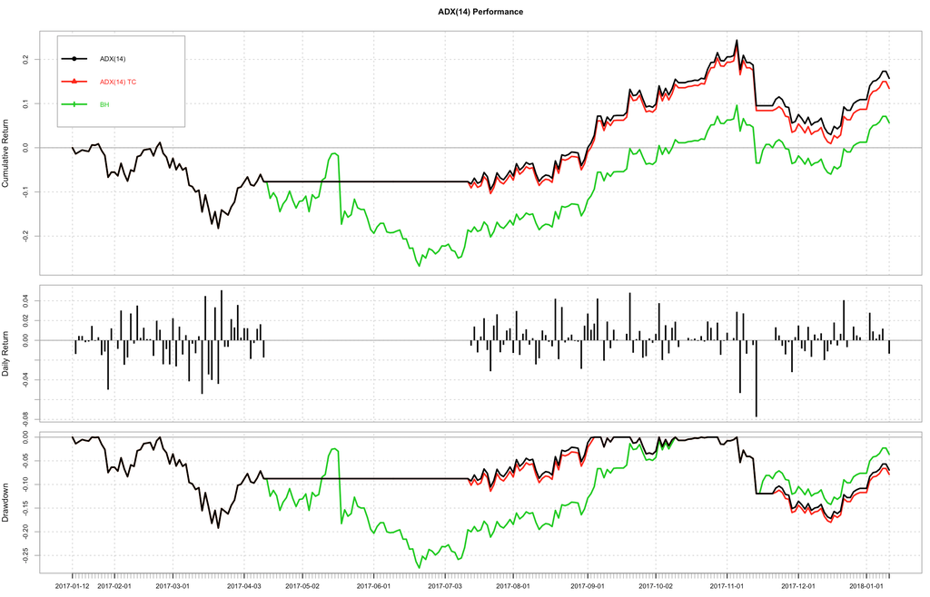

Sumário de Performance PETR4

#### BBAS3

Melhores Estratégias:

```
 estrategiasVencedoras     valoresRetornoVencedores
```

[1,] “SMA(5,21)” “0.1521”  
[2,] “ADX(14)” “0.3666”  
[3,] “ROC(21)” “0.2305”  
[4,] “RSI(14)” “0.2623”  
[5,] “ROC(21) & SMA(5)” “0.1897”  
[6,] “RSI(14) & SMA(5)” “0.252”  
[7,] “SMI(13,2,25,9) & SMA(5)” “0.242”  
[8,] “%R(14) & SMA(5)” “0.2806”

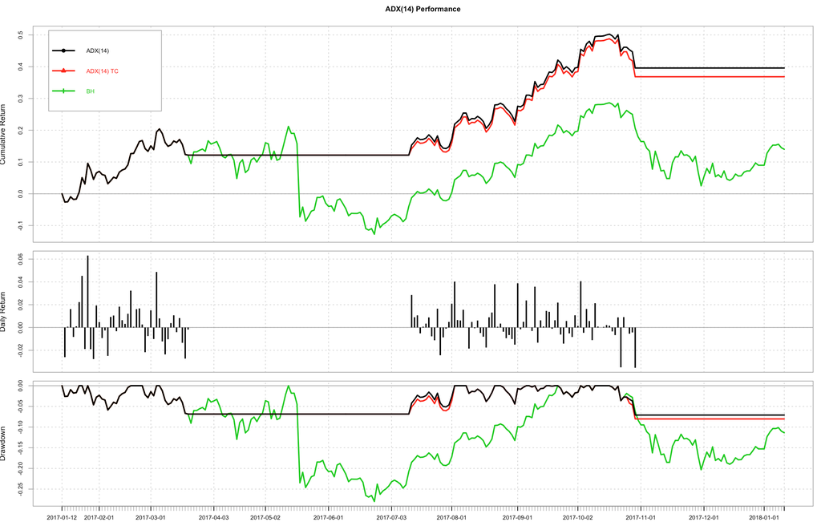

Sumário de Performance BBAS3

#### VALE5

Melhores Estratégias:

```
 estrategiasVencedoras valoresRetornoVencedores
```

[1,] “SMA(5,21)” “0.2706”  
[2,] “BB(20,2)” “0.4006”  
[3,] “CCI(20,0.015)” “0.2529”

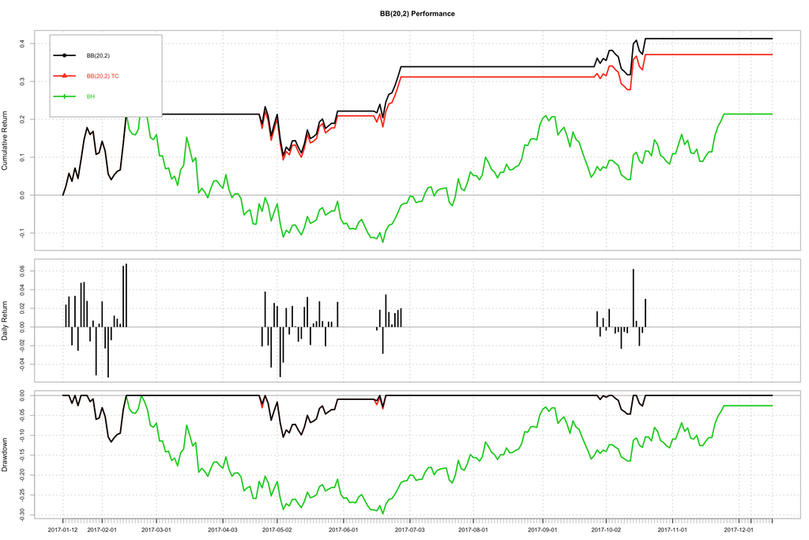

Sumário de Performance VALE5